# Predict Bike Sharing Demand with AutoGluon

### Install packages

```python
!pip install kaggle
!pip install ipywidgets
!pip install autogluon --no-cache-dir
# Without --no-cache-dir, smaller aws instances may have trouble installing
```

### Download and explore dataset

```python
# Download the dataset, it will be in a .zip file so you'll need to unzip it as well.
!kaggle competitions download -c bike-sharing-demand
# If you already downloaded it you can use the -o command to overwrite the file
!unzip -o bike-sharing-demand.zip
```

```
bike-sharing-demand.zip: Skipping, found more recently modified local copy (use --force to force download)
Archive:  bike-sharing-demand.zip
  inflating: sampleSubmission.csv
  inflating: test.csv
  inflating: train.csv
```

```python
import pandas as pd
from autogluon.tabular import TabularPredictor
import time
import seaborn as sns
import matplotlib.pyplot as plt
%matplotlib inline
```

```python
# Create the train dataset in pandas by reading the csv
# Set the parsing of the datetime column so you can use some of the `dt` features in pandas later
train = pd.read_csv('train.csv')
train.head()
```

|  | datetime | season | holiday | workingday | weather | temp | atemp | humidity | windspeed | casual | registered | count |
| --- | --- | --- | --- | --- | --- | --- | --- | --- | --- | --- | --- | --- |
| 0 | 2011-01-01 00:00:00 | 1 | 0 | 0 | 1 | 9.84 | 14.395 | 81 | 0.0 | 3 | 13 | 16 |
| 1 | 2011-01-01 01:00:00 | 1 | 0 | 0 | 1 | 9.02 | 13.635 | 80 | 0.0 | 8 | 32 | 40 |
| 2 | 2011-01-01 02:00:00 | 1 | 0 | 0 | 1 | 9.02 | 13.635 | 80 | 0.0 | 5 | 27 | 32 |
| 3 | 2011-01-01 03:00:00 | 1 | 0 | 0 | 1 | 9.84 | 14.395 | 75 | 0.0 | 3 | 10 | 13 |
| 4 | 2011-01-01 04:00:00 | 1 | 0 | 0 | 1 | 9.84 | 14.395 | 75 | 0.0 | 0 | 1 | 1 |

```python
# Simple output of the train dataset to view some of the min/max/varition of the dataset features.
train.describe()
```

|  | season | holiday | workingday | weather | temp | atemp | humidity | windspeed | casual | registered | count |
| --- | --- | --- | --- | --- | --- | --- | --- | --- | --- | --- | --- |
| count | 10886.000000 | 10886.000000 | 10886.000000 | 10886.000000 | 10886.00000 | 10886.000000 | 10886.000000 | 10886.000000 | 10886.000000 | 10886.000000 | 10886.000000 |
| mean | 2.506614 | 0.028569 | 0.680875 | 1.418427 | 20.23086 | 23.655084 | 61.886460 | 12.799395 | 36.021955 | 155.552177 | 191.574132 |
| std | 1.116174 | 0.166599 | 0.466159 | 0.633839 | 7.79159 | 8.474601 | 19.245033 | 8.164537 | 49.960477 | 151.039033 | 181.144454 |
| min | 1.000000 | 0.000000 | 0.000000 | 1.000000 | 0.82000 | 0.760000 | 0.000000 | 0.000000 | 0.000000 | 0.000000 | 1.000000 |
| 25% | 2.000000 | 0.000000 | 0.000000 | 1.000000 | 13.94000 | 16.665000 | 47.000000 | 7.001500 | 4.000000 | 36.000000 | 42.000000 |
| 50% | 3.000000 | 0.000000 | 1.000000 | 1.000000 | 20.50000 | 24.240000 | 62.000000 | 12.998000 | 17.000000 | 118.000000 | 145.000000 |
| 75% | 4.000000 | 0.000000 | 1.000000 | 2.000000 | 26.24000 | 31.060000 | 77.000000 | 16.997900 | 49.000000 | 222.000000 | 284.000000 |
| max | 4.000000 | 1.000000 | 1.000000 | 4.000000 | 41.00000 | 45.455000 | 100.000000 | 56.996900 | 367.000000 | 886.000000 | 977.000000 |

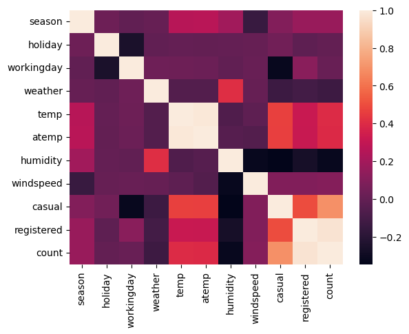

```python
train_data_feature_correlation = sns.heatmap(train.drop('datetime', axis=1).corr());
train_data_feature_correlation.figure.savefig('img/train_data_feature_correlation.png')
```

```python
# Create the test pandas dataframe in pandas by reading the csv, remember to parse the datetime!
test = pd.read_csv('test.csv')
test.head()
```

|  | datetime | season | holiday | workingday | weather | temp | atemp | humidity | windspeed |
| --- | --- | --- | --- | --- | --- | --- | --- | --- | --- |
| 0 | 2011-01-20 00:00:00 | 1 | 0 | 1 | 1 | 10.66 | 11.365 | 56 | 26.0027 |
| 1 | 2011-01-20 01:00:00 | 1 | 0 | 1 | 1 | 10.66 | 13.635 | 56 | 0.0000 |
| 2 | 2011-01-20 02:00:00 | 1 | 0 | 1 | 1 | 10.66 | 13.635 | 56 | 0.0000 |
| 3 | 2011-01-20 03:00:00 | 1 | 0 | 1 | 1 | 10.66 | 12.880 | 56 | 11.0014 |
| 4 | 2011-01-20 04:00:00 | 1 | 0 | 1 | 1 | 10.66 | 12.880 | 56 | 11.0014 |

```python
# Same thing as train and test dataset
submission = pd.read_csv('sampleSubmission.csv')
submission.head()
```

|  | datetime | count |
| --- | --- | --- |
| 0 | 2011-01-20 00:00:00 | 0 |
| 1 | 2011-01-20 01:00:00 | 0 |
| 2 | 2011-01-20 02:00:00 | 0 |
| 3 | 2011-01-20 03:00:00 | 0 |
| 4 | 2011-01-20 04:00:00 | 0 |

## Step 3: Train a model using AutoGluon’s Tabular Prediction

Requirements:

- We are predicting `count`, so it is the label we are setting.
- Ignore `casual` and `registered` columns as they are also not present in the test dataset.
- Use the `root_mean_squared_error` as the metric to use for evaluation.
- Set a time limit of 10 minutes (600 seconds).
- Use the preset `best_quality` to focus on creating the best model.

```python
predictor = TabularPredictor(label='count', eval_metric='root_mean_squared_error').fit(
    train_data=train.drop(['casual', 'registered'], axis=1),
    time_limit=600,
    presets='best_quality')
```

### Review AutoGluon's training run with ranking of models that did the best.

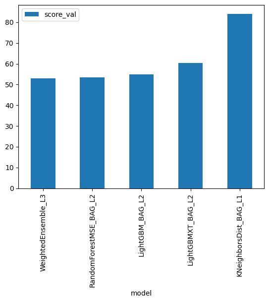

```python
leaderboard = predictor.leaderboard()[:5]
leaderboard['score_val'] = leaderboard['score_val'] * -1
initial_model_performance_img = leaderboard.plot(kind='bar', x='model', y='score_val');
initial_model_performance_img.figure.savefig('img/initial_model_performance_img.png')
```

```python
predictor.leaderboard().head()
```

|  | model | score_val | eval_metric | pred_time_val | fit_time | pred_time_val_marginal | fit_time_marginal | stack_level | can_infer | fit_order |
| --- | --- | --- | --- | --- | --- | --- | --- | --- | --- | --- |
| 0 | WeightedEnsemble_L3 | -53.043357 | root_mean_squared_error | 22.281742 | 393.365883 | 0.001471 | 0.057156 | 3 | True | 13 |
| 1 | RandomForestMSE_BAG_L2 | -53.376872 | root_mean_squared_error | 17.115719 | 313.048331 | 0.621194 | 42.336201 | 2 | True | 12 |
| 2 | LightGBM_BAG_L2 | -54.925102 | root_mean_squared_error | 16.818487 | 291.980293 | 0.323962 | 21.268163 | 2 | True | 11 |
| 3 | LightGBMXT_BAG_L2 | -60.460602 | root_mean_squared_error | 21.335115 | 329.704363 | 4.840590 | 58.992234 | 2 | True | 10 |
| 4 | KNeighborsDist_BAG_L1 | -84.125061 | root_mean_squared_error | 0.082157 | 0.050270 | 0.082157 | 0.050270 | 1 | True | 2 |

```python
initial_model_eval_score = leaderboard['score_val'][0]
```

### Create predictions from test dataset

```python
predictions = predictor.predict(test)
predictions.head()
```

```
0    22.582388
1    41.871078
2    46.105045
3    48.217484
4    50.980785
Name: count, dtype: float32
```

#### NOTE: Kaggle will reject the submission if we don't set everything to be > 0.

```python
# Describe the `predictions` series to see if there are any negative values
predictions.describe()
```

```
count    6493.000000
mean      100.501915
std        90.065346
min         2.937466
25%        19.789762
50%        63.525288
75%       167.939240
max       369.398193
Name: count, dtype: float64
```

```python
# How many negative values do we have?
predictions[predictions < 0]
```

```
Series([], Name: count, dtype: float32)
```

```python
# Set them to zero
predictions[predictions < 0] = 0
```

### Set predictions to submission dataframe, save, and submit

```python
submission["count"] = predictions
submission.to_csv("submission.csv", index=False)
```

```python
!kaggle competitions submit -c bike-sharing-demand -f submission.csv -m "first raw submission"
```

```
Successfully submitted to Bike Sharing Demand
```

#### View submission via the command line or in the web browser under the competition's page - `My Submissions`

```python
time.sleep(5)
!kaggle competitions submissions -c bike-sharing-demand | tail -n +1 | head -n 6
```

```
fileName                                                             date                 description                                           status    publicScore  privateScore
-------------------------------------------------------------------  -------------------  ----------------------------------------------------  --------  -----------  ------------
submission.csv                                                       2024-04-27 15:47:58  first raw submission                                  complete  1.80625      1.80625
submission_best_models_stacking_top5_ExtraTrees_BAG_L2.csv           2024-04-27 14:44:51  best models stacking top5 ExtraTrees_BAG_L2           complete  0.44801      0.44801
submission_best_models_stacking_top5_WeightedEnsemble_L2.csv         2024-04-27 14:44:46  best models stacking top5 WeightedEnsemble_L2         complete  0.52252      0.52252
submission_best_models_stacking_top5_CatBoost_BAG_L2_T1.csv          2024-04-27 14:44:42  best models stacking top5 CatBoost_BAG_L2/T1          complete  0.45117      0.45117
tail: error writing 'standard output': Broken pipe
```

```python
output_k = !kaggle competitions submissions -c bike-sharing-demand | tail -n +1 | head -n 6
initial_model_kaggle_score = output_k[2].split()[-1]
```

## Step 4: Exploratory Data Analysis and Creating an additional feature

- Any additional feature will do, but a great suggestion would be to separate out the datetime into hour, day, or month parts.

```python
train = pd.read_csv('train.csv')
test = pd.read_csv('test.csv')
```

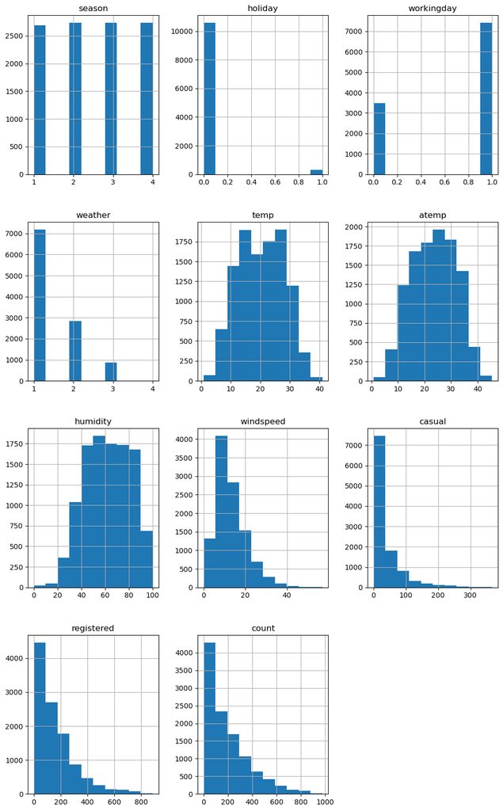

```python
# Create a histogram of all features to show the distribution of each one relative to the data. This is part of the exploritory data analysis
train_hist_img = train.hist(figsize=(12, 20));
```

```python
train.info()
```

```
<class 'pandas.core.frame.DataFrame'>
RangeIndex: 10886 entries, 0 to 10885
Data columns (total 12 columns):
 #   Column      Non-Null Count  Dtype
---  ------      --------------  -----
 0   datetime    10886 non-null  object
 1   season      10886 non-null  int64
 2   holiday     10886 non-null  int64
 3   workingday  10886 non-null  int64
 4   weather     10886 non-null  int64
 5   temp        10886 non-null  float64
 6   atemp       10886 non-null  float64
 7   humidity    10886 non-null  int64
 8   windspeed   10886 non-null  float64
 9   casual      10886 non-null  int64
 10  registered  10886 non-null  int64
 11  count       10886 non-null  int64
dtypes: float64(3), int64(8), object(1)
memory usage: 1020.7+ KB
```

```python
train.describe()
```

|  | season | holiday | workingday | weather | temp | atemp | humidity | windspeed | casual | registered | count |
| --- | --- | --- | --- | --- | --- | --- | --- | --- | --- | --- | --- |
| count | 10886.000000 | 10886.000000 | 10886.000000 | 10886.000000 | 10886.00000 | 10886.000000 | 10886.000000 | 10886.000000 | 10886.000000 | 10886.000000 | 10886.000000 |
| mean | 2.506614 | 0.028569 | 0.680875 | 1.418427 | 20.23086 | 23.655084 | 61.886460 | 12.799395 | 36.021955 | 155.552177 | 191.574132 |
| std | 1.116174 | 0.166599 | 0.466159 | 0.633839 | 7.79159 | 8.474601 | 19.245033 | 8.164537 | 49.960477 | 151.039033 | 181.144454 |
| min | 1.000000 | 0.000000 | 0.000000 | 1.000000 | 0.82000 | 0.760000 | 0.000000 | 0.000000 | 0.000000 | 0.000000 | 1.000000 |
| 25% | 2.000000 | 0.000000 | 0.000000 | 1.000000 | 13.94000 | 16.665000 | 47.000000 | 7.001500 | 4.000000 | 36.000000 | 42.000000 |
| 50% | 3.000000 | 0.000000 | 1.000000 | 1.000000 | 20.50000 | 24.240000 | 62.000000 | 12.998000 | 17.000000 | 118.000000 | 145.000000 |
| 75% | 4.000000 | 0.000000 | 1.000000 | 2.000000 | 26.24000 | 31.060000 | 77.000000 | 16.997900 | 49.000000 | 222.000000 | 284.000000 |
| max | 4.000000 | 1.000000 | 1.000000 | 4.000000 | 41.00000 | 45.455000 | 100.000000 | 56.996900 | 367.000000 | 886.000000 | 977.000000 |

```python
# create a new feature
train['datetime'] = pd.to_datetime(train['datetime'])
train['hour'] = train.datetime.dt.hour
train['day'] = train.datetime.dt.day
train['month'] = train.datetime.dt.month

test['datetime'] = pd.to_datetime(test['datetime'])
test['hour'] = test.datetime.dt.hour
test['day'] = test.datetime.dt.day
test['month'] = test.datetime.dt.month
```

```python
# Feature that categorizes morning, lunch, and evening rush hour, 7-9am, 11am-1pm, and 5-6pm
def categorize_rush_hours(hour):
    morning = range(7, 10)
    lunch = range(11, 14)
    evening = range(17, 19)

    if hour in morning:
        return 1
    if hour in lunch:
        return 2
    if hour in evening:
        return 3
    return 0

train['rush_hours'] = train['hour'].apply(categorize_rush_hours)
test['rush_hours'] = test['hour'].apply(categorize_rush_hours)
```

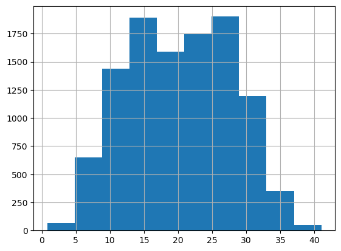

```python
train['temp'].hist();
```

```python
def categorize_temp(temp):
    cold = 16
    hot = 25

    if temp < cold:
        return 1
    if temp >= cold and temp < hot:
        return 2
    if temp >= hot:
        return 3

train['temp_cat'] = train['temp'].apply(categorize_temp)
test['temp_cat'] = test['temp'].apply(categorize_temp)
```

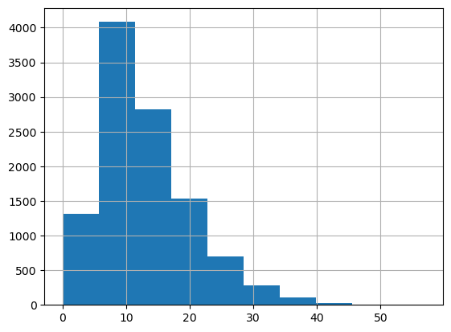

```python
train['windspeed'].hist();
```

```python
def categorize_wind(windspeed):
    windy = 12
    very_windy = 25

    if windspeed < windy:
        return 0
    if windspeed >= windy and windspeed < very_windy:
        return 1
    if windspeed >= very_windy:
        return 2

train['wind_cat'] = train['windspeed'].apply(categorize_wind)
test['wind_cat'] = test['windspeed'].apply(categorize_wind)
```

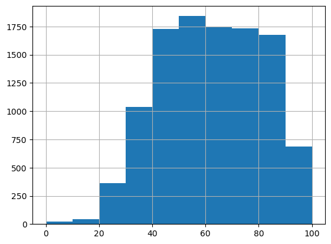

```python
train['humidity'].hist();
```

```python
def categorize_humidity(humidity):
    not_humid = 20
    humid = 75

    if humidity < not_humid:
        return 0
    if humidity >= not_humid and humidity < humid:
        return 1
    return 2

train['humid_cat'] = train['humidity'].apply(categorize_humidity)
test['humid_cat'] = test['humidity'].apply(categorize_humidity)
```

## Make category types for these so models know they are not just numbers

- AutoGluon originally sees these as ints, but in reality they are int representations of a category.
- Setting the dtype to category will classify these as categories in AutoGluon.

```python
train["season"] = train["season"].astype('category')
train["weather"] = train["weather"].astype('category')
train["rush_hours"] = train["rush_hours"].astype('category')
train["temp_cat"] = train["temp_cat"].astype('category')
train["wind_cat"] = train["wind_cat"].astype('category')
train["humid_cat"] = train["humid_cat"].astype('category')

test["season"] = test["season"].astype('category')
test["weather"] = test["weather"].astype('category')
test["rush_hours"] = test["rush_hours"].astype('category')
test["temp_cat"] = test["temp_cat"].astype('category')
test["wind_cat"] = test["wind_cat"].astype('category')
test["humid_cat"] = test["humid_cat"].astype('category')
```

```python
# View are new feature
train.head()
```

|  | datetime | season | holiday | workingday | weather | temp | atemp | humidity | windspeed | casual | registered | count | hour | day | month | rush_hours | temp_cat | wind_cat | humid_cat |
| --- | --- | --- | --- | --- | --- | --- | --- | --- | --- | --- | --- | --- | --- | --- | --- | --- | --- | --- | --- |
| 0 | 2011-01-01 00:00:00 | 1 | 0 | 0 | 1 | 9.84 | 14.395 | 81 | 0.0 | 3 | 13 | 16 | 0 | 1 | 1 | 0 | 1 | 0 | 2 |
| 1 | 2011-01-01 01:00:00 | 1 | 0 | 0 | 1 | 9.02 | 13.635 | 80 | 0.0 | 8 | 32 | 40 | 1 | 1 | 1 | 0 | 1 | 0 | 2 |
| 2 | 2011-01-01 02:00:00 | 1 | 0 | 0 | 1 | 9.02 | 13.635 | 80 | 0.0 | 5 | 27 | 32 | 2 | 1 | 1 | 0 | 1 | 0 | 2 |
| 3 | 2011-01-01 03:00:00 | 1 | 0 | 0 | 1 | 9.84 | 14.395 | 75 | 0.0 | 3 | 10 | 13 | 3 | 1 | 1 | 0 | 1 | 0 | 2 |
| 4 | 2011-01-01 04:00:00 | 1 | 0 | 0 | 1 | 9.84 | 14.395 | 75 | 0.0 | 0 | 1 | 1 | 4 | 1 | 1 | 0 | 1 | 0 | 2 |

```python
train.info()
```

```
<class 'pandas.core.frame.DataFrame'>
RangeIndex: 10886 entries, 0 to 10885
Data columns (total 19 columns):
 #   Column      Non-Null Count  Dtype
---  ------      --------------  -----
 0   datetime    10886 non-null  datetime64[ns]
 1   season      10886 non-null  category
 2   holiday     10886 non-null  int64
 3   workingday  10886 non-null  int64
 4   weather     10886 non-null  category
 5   temp        10886 non-null  float64
 6   atemp       10886 non-null  float64
 7   humidity    10886 non-null  int64
 8   windspeed   10886 non-null  float64
 9   casual      10886 non-null  int64
 10  registered  10886 non-null  int64
 11  count       10886 non-null  int64
 12  hour        10886 non-null  int32
 13  day         10886 non-null  int32
 14  month       10886 non-null  int32
 15  rush_hours  10886 non-null  category
 16  temp_cat    10886 non-null  category
 17  wind_cat    10886 non-null  category
 18  humid_cat   10886 non-null  category
dtypes: category(6), datetime64[ns](1), float64(3), int32(3), int64(6)
memory usage: 1.0 MB
```

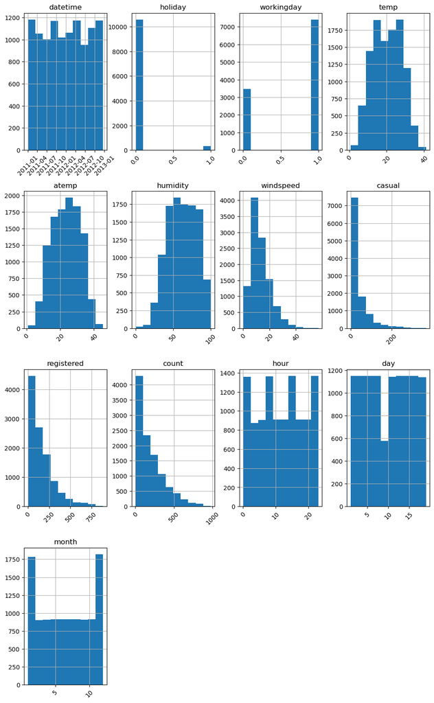

```python
# View histogram of all features again now with the hour feature
new_features_train_hist_img = train.hist(figsize=(12, 20), xrot=45);
```

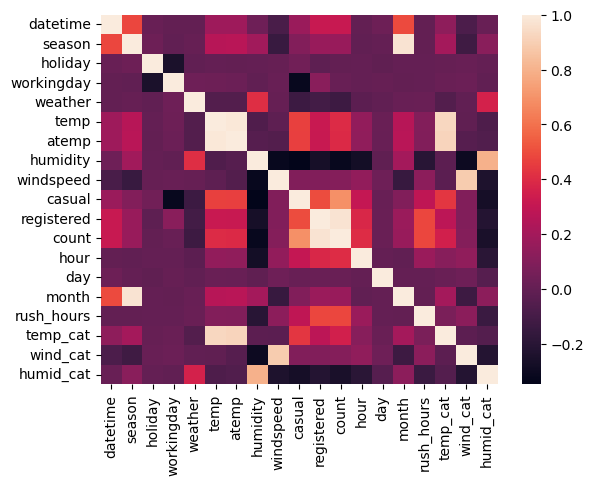

```python
new_features_train_data_feature_correlation = sns.heatmap(train.corr());
new_features_train_data_feature_correlation.figure.savefig('img/new_features_train_data_feature_correlation.png')
```

## Step 5: Rerun the model with the same settings as before, just with more features

```python
predictor_new_features = TabularPredictor(label='count', eval_metric='root_mean_squared_error').fit(
    train_data=train.drop(['casual', 'registered'], axis=1),
    time_limit=600,
    presets='best_quality')
```

```python
def submit_top5(predictor, test, file_prefix, msg_prefix):
    model_to_use = predictor.leaderboard().model
    for model in model_to_use[:5]:
        prediction_top5 = predictor.predict(test, model=model)
        prediction_top5[prediction_top5 < 0] = 0
        submission_top5 = pd.read_csv('sampleSubmission.csv')
        submission_top5["count"] = prediction_top5
        filename = f"{file_prefix}_{model}.csv".replace('/', '_')
        submission_top5.to_csv(filename, index=False)
        !kaggle competitions submit -c bike-sharing-demand -f {filename} -m "{msg_prefix} {model}"


def get_submission_score(predictor):
    output_k = !kaggle competitions submissions -c bike-sharing-demand | tail -n +1 | head -n 9
    submission_results = [float(output_k[i].split()[-1]) for i in range(6, 1, -1)]

    leaderboard = predictor.leaderboard()[:5]
    leaderboard['score_val'] = leaderboard['score_val'] * -1
    leaderboard['subm_score'] = submission_results

    eval_score = leaderboard['score_val'][0]
    kaggle_score = sorted(submission_results)[0]

    return leaderboard, eval_score, kaggle_score


def plot_eval_and_kaggle_scores(leaderboard, path):
    fig, axes = plt.subplots(nrows=1,ncols=2, figsize=(20,6))
    leaderboard.plot(kind='bar', x='model', y='score_val', ax = axes[0], subplots=True)
    leaderboard.plot(kind='bar', x='model', y='subm_score', color='red', ax = axes[1], subplots=True)
    fig.savefig(path)
```

```python
submit_top5(predictor_new_features, test, 'submission_new_features_top5', 'new features top5')
```

```
Successfully submitted to Bike Sharing Demand
```

```python
time.sleep(10)
!kaggle competitions submissions -c bike-sharing-demand | tail -n +1 | head -n 9
```

```
fileName                                                             date                 description                                           status    publicScore  privateScore
-------------------------------------------------------------------  -------------------  ----------------------------------------------------  --------  -----------  ------------
submission_new_features_top5_CatBoost_BAG_L2.csv                     2024-04-27 16:08:56  new features top5 CatBoost_BAG_L2                     complete  0.64322      0.64322
submission_new_features_top5_RandomForestMSE_BAG_L2.csv              2024-04-27 16:07:28  new features top5 RandomForestMSE_BAG_L2              complete  0.48384      0.48384
submission_new_features_top5_LightGBMXT_BAG_L2.csv                   2024-04-27 16:05:59  new features top5 LightGBMXT_BAG_L2                   complete  0.6627       0.6627
submission_new_features_top5_LightGBM_BAG_L2.csv                     2024-04-27 16:04:26  new features top5 LightGBM_BAG_L2                     complete  0.61189      0.61189
submission_new_features_top5_WeightedEnsemble_L3.csv                 2024-04-27 16:02:55  new features top5 WeightedEnsemble_L3                 complete  0.60417      0.60417
submission.csv                                                       2024-04-27 15:47:58  first raw submission                                  complete  1.80625      1.80625
submission_best_models_stacking_top5_ExtraTrees_BAG_L2.csv           2024-04-27 14:44:51  best models stacking top5 ExtraTrees_BAG_L2           complete  0.44801      0.44801
tail: error writing 'standard output': Broken pipe
```

```python
new_features_leaderboard, new_features_model_eval_score, new_features_model_kaggle_score = get_submission_score(predictor_new_features)
```

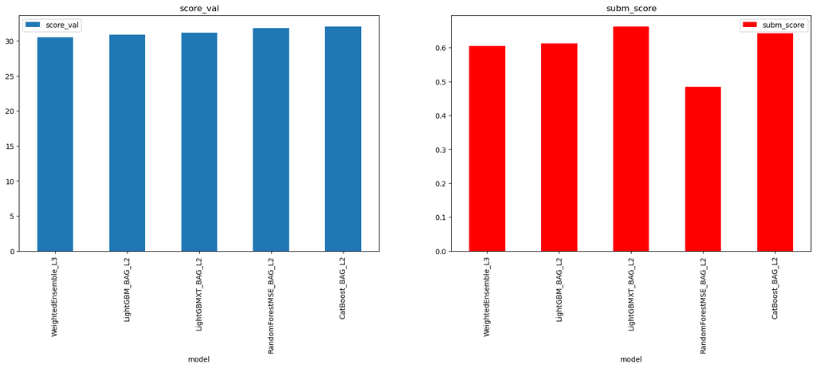

```python
plot_eval_and_kaggle_scores(new_features_leaderboard, 'img/new_features_leaderboard.png')
```

Remove features that are highly correlated

```python
predictor_new_features_plus_remove = TabularPredictor(label='count', eval_metric='root_mean_squared_error').fit(
    train_data=train.drop(['casual', 'registered', 'temp', 'atemp', 'windspeed', 'humidity', 'month'], axis=1),
    time_limit=600,
    presets='best_quality')
```

```python
submit_top5(predictor_new_features_plus_remove,
            test.drop(['temp', 'atemp', 'windspeed', 'humidity', 'month'], axis=1),
            'submission_new_features_plus_remove_top5',
            'new features plus remove top5')
```

```
Successfully submitted to Bike Sharing Demand
```

```python
time.sleep(10)
!kaggle competitions submissions -c bike-sharing-demand | tail -n +1 | head -n 9
```

```
fileName                                                             date                 description                                           status    publicScore  privateScore
-------------------------------------------------------------------  -------------------  ----------------------------------------------------  --------  -----------  ------------
submission_new_features_plus_remove_top5_WeightedEnsemble_L2.csv     2024-04-27 16:29:02  new features plus remove top5 WeightedEnsemble_L2     complete  0.55105      0.55105
submission_new_features_plus_remove_top5_RandomForestMSE_BAG_L2.csv  2024-04-27 16:27:08  new features plus remove top5 RandomForestMSE_BAG_L2  complete  0.51195      0.51195
submission_new_features_plus_remove_top5_LightGBMXT_BAG_L2.csv       2024-04-27 16:25:15  new features plus remove top5 LightGBMXT_BAG_L2       complete  0.69137      0.69137
submission_new_features_plus_remove_top5_LightGBM_BAG_L2.csv         2024-04-27 16:23:14  new features plus remove top5 LightGBM_BAG_L2         complete  0.6719       0.6719
submission_new_features_plus_remove_top5_WeightedEnsemble_L3.csv     2024-04-27 16:21:24  new features plus remove top5 WeightedEnsemble_L3     complete  0.66042      0.66042
submission_new_features_top5_CatBoost_BAG_L2.csv                     2024-04-27 16:08:56  new features top5 CatBoost_BAG_L2                     complete  0.64322      0.64322
submission_new_features_top5_RandomForestMSE_BAG_L2.csv              2024-04-27 16:07:28  new features top5 RandomForestMSE_BAG_L2              complete  0.48384      0.48384
tail: write error: Broken pipe
```

```python
new_features_plus_remove_leaderboard, new_feature_plus_remove_model_eval_score, new_feature_plus_remove_model_kaggle_score = get_submission_score(predictor_new_features_plus_remove)
```

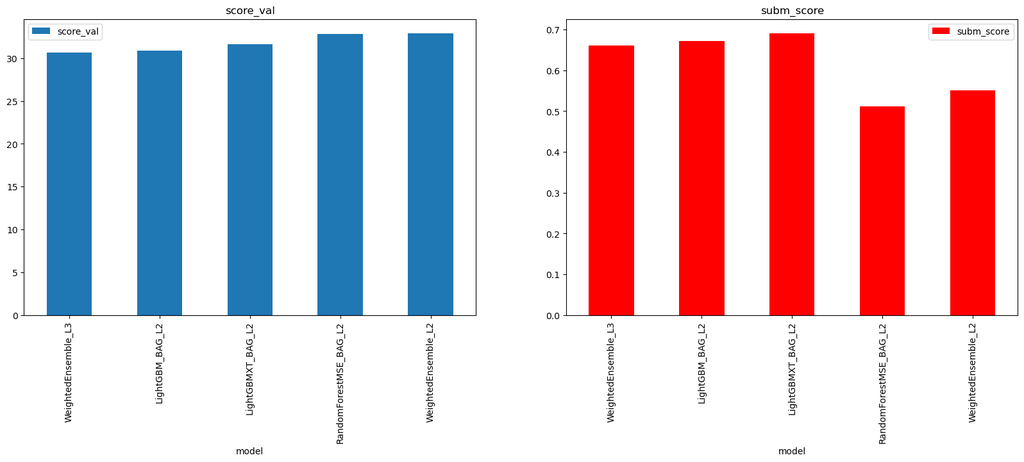

```python
plot_eval_and_kaggle_scores(new_features_plus_remove_leaderboard, 'img/new_features_plus_remove_leaderboard.png')
```

## Step 6: Hyper parameter optimization

- There are many options for hyper parameter optimization.
- Options are to change the AutoGluon higher level parameters or the individual model hyperparameters.
- The hyperparameters of the models themselves that are in AutoGluon. Those need the `hyperparameter` and `hyperparameter_tune_kwargs` arguments.

```python
predictor_new_hpo_time = TabularPredictor(label='count', eval_metric='root_mean_squared_error').fit(
    train.drop(['registered', 'casual'], axis=1),
    time_limit=1200,
    presets='best_quality',
)
```

```python
submit_top5(predictor_new_hpo_time, test, 'submission_new_hpo_time_top5', 'new hpo time top5')
```

```
Successfully submitted to Bike Sharing Demand
```

```python
time.sleep(10)
!kaggle competitions submissions -c bike-sharing-demand | tail -n +1 | head -n 9
```

```
fileName                                                             date                 description                                           status    publicScore  privateScore
-------------------------------------------------------------------  -------------------  ----------------------------------------------------  --------  -----------  ------------
submission_new_hpo_time_top5_ExtraTreesMSE_BAG_L2.csv                2024-04-27 16:56:50  new hpo time top5 ExtraTreesMSE_BAG_L2                complete  0.48547      0.48547
submission_new_hpo_time_top5_LightGBMXT_BAG_L2.csv                   2024-04-27 16:55:21  new hpo time top5 LightGBMXT_BAG_L2                   complete  0.6505       0.6505
submission_new_hpo_time_top5_CatBoost_BAG_L2.csv                     2024-04-27 16:53:48  new hpo time top5 CatBoost_BAG_L2                     complete  0.77179      0.77179
submission_new_hpo_time_top5_LightGBM_BAG_L2.csv                     2024-04-27 16:52:27  new hpo time top5 LightGBM_BAG_L2                     complete  0.62222      0.62222
submission_new_hpo_time_top5_WeightedEnsemble_L3.csv                 2024-04-27 16:50:58  new hpo time top5 WeightedEnsemble_L3                 complete  0.66165      0.66165
submission_new_features_plus_remove_top5_WeightedEnsemble_L2.csv     2024-04-27 16:29:02  new features plus remove top5 WeightedEnsemble_L2     complete  0.55105      0.55105
submission_new_features_plus_remove_top5_RandomForestMSE_BAG_L2.csv  2024-04-27 16:27:08  new features plus remove top5 RandomForestMSE_BAG_L2  complete  0.51195      0.51195
tail: error writing 'standard output': Broken pipe
```

```python
new_hpo_time_leaderboard, new_hpo_time_model_eval_score, new_hpo_time_model_kaggle_score = get_submission_score(predictor_new_hpo_time)
```

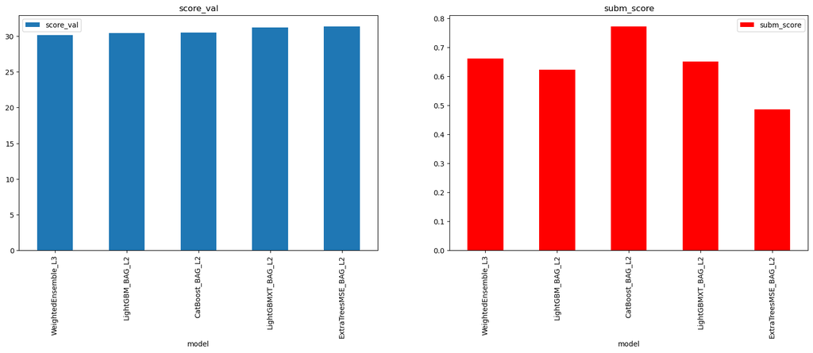

```python
plot_eval_and_kaggle_scores(new_hpo_time_leaderboard, 'img/new_hpo_time_leaderboard.png')
```

```python
predictor_stacking = TabularPredictor(label='count', eval_metric='root_mean_squared_error').fit(
    train.drop(['registered', 'casual'], axis=1),
    num_bag_folds=7, num_bag_sets=2, num_stack_levels=2,
    time_limit=1200,
    presets='best_quality',
)
```

```python
submit_top5(predictor_stacking, test, 'submission_stacking_top5', 'stacking top5')
```

```
Successfully submitted to Bike Sharing Demand
```

```python
time.sleep(10)
!kaggle competitions submissions -c bike-sharing-demand | tail -n +1 | head -n 9
```

```
fileName                                                             date                 description                                           status    publicScore  privateScore
-------------------------------------------------------------------  -------------------  ----------------------------------------------------  --------  -----------  ------------
submission_stacking_top5_CatBoost_BAG_L3.csv                         2024-04-27 17:23:25  stacking top5 CatBoost_BAG_L3                         complete  0.607        0.607
submission_stacking_top5_LightGBM_BAG_L2.csv                         2024-04-27 17:22:02  stacking top5 LightGBM_BAG_L2                         complete  0.61444      0.61444
submission_stacking_top5_CatBoost_BAG_L2.csv                         2024-04-27 17:20:53  stacking top5 CatBoost_BAG_L2                         complete  0.79828      0.79828
submission_stacking_top5_WeightedEnsemble_L3.csv                     2024-04-27 17:19:46  stacking top5 WeightedEnsemble_L3                     complete  0.71754      0.71754
submission_stacking_top5_WeightedEnsemble_L4.csv                     2024-04-27 17:18:33  stacking top5 WeightedEnsemble_L4                     complete  0.71754      0.71754
submission_new_hpo_time_top5_ExtraTreesMSE_BAG_L2.csv                2024-04-27 16:56:50  new hpo time top5 ExtraTreesMSE_BAG_L2                complete  0.48547      0.48547
submission_new_hpo_time_top5_LightGBMXT_BAG_L2.csv                   2024-04-27 16:55:21  new hpo time top5 LightGBMXT_BAG_L2                   complete  0.6505       0.6505
tail: error writing 'standard output': Broken pipe
```

```python
stacking_leaderboard, stacking_model_eval_score, stacking_model_kaggle_score = get_submission_score(predictor_stacking)
```

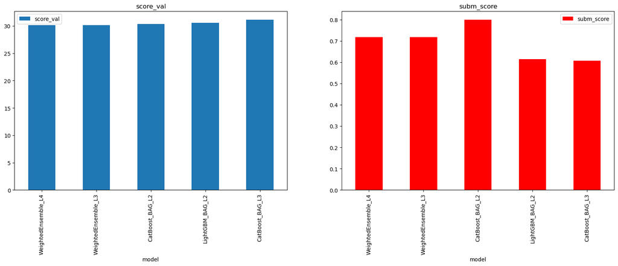

```python
plot_eval_and_kaggle_scores(stacking_leaderboard, 'img/stacking_leaderboard.png')
```

```python
models_to_train = ['NN_TORCH', 'GBM', 'CAT', 'XGB', 'FASTAI', 'RF', 'XT', 'KNN']
solo_model_leaderboard = {model: [] for model in models_to_train}

for model in models_to_train:
    predictor_solo_model = TabularPredictor(label='count', eval_metric='root_mean_squared_error').fit(
        train.drop(['registered', 'casual'], axis=1),
        time_limit=150,
        presets='best_quality',
        hyperparameters={model: {}}
    )

    best_model = predictor_solo_model.model_best
    solo_model_leaderboard[model] = (best_model, predictor_solo_model.leaderboard()['score_val'][0])

    prediction_solo_model = predictor_solo_model.predict(test)
    prediction_solo_model[prediction_solo_model < 0] = 0
    submission_solo_model = pd.read_csv('sampleSubmission.csv')
    submission_solo_model["count"] = prediction_solo_model
    filename = f"solo_{model}.csv"
    submission_solo_model.to_csv(filename, index=False)
    !kaggle competitions submit -c bike-sharing-demand -f {filename} -m "solo model {model}"
```

```python
time.sleep(10)
!kaggle competitions submissions -c bike-sharing-demand | tail -n +1 | head -n 10
```

[output not shown]

```python
output_k = !kaggle competitions submissions -c bike-sharing-demand | tail -n +1 | head -n 10
submission_results = [float(output_k[i].split()[-1]) for i in range(9, 1, -1)]
```

```python
for_df = {'model': [], 'score_val': []}
for key, value in solo_model_leaderboard.items():
    for_df['model'].append(key)
    for_df['score_val'].append(value[1] * -1)
```

```python
solo_model_df = pd.DataFrame(for_df)
solo_model_df['subm_score'] = submission_results
solo_model_df.head()
```

|  | model | score_val | subm_score |
| --- | --- | --- | --- |
| 0 | NN_TORCH | 71.103371 | 0.89741 |
| 1 | GBM | 33.693683 | 0.51915 |
| 2 | CAT | 38.304002 | 0.48614 |
| 3 | XGB | 34.072702 | 0.57259 |
| 4 | FASTAI | 57.721693 | 0.75613 |

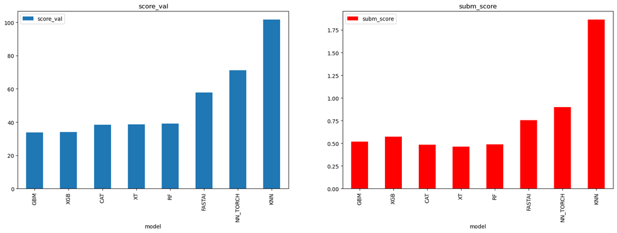

```python
plot_eval_and_kaggle_scores(solo_model_df.sort_values(by='score_val'), 'img/solo_model_df.png')
```

```python
solo_model_eval_score, solo_model_kaggle_score = solo_model_df['score_val'].min(), solo_model_df['subm_score'].min()
```

```python
hyperparameters = {
                    'RF': {},
                    'CAT': {},
                    'XT': {}
                  }

time_limit = 1200
num_trials = 5
search_strategy = 'auto'

hyperparameter_tune_kwargs = {
    'num_trials': num_trials,
    'scheduler' : 'local',
    'searcher': search_strategy,}
```

```python
predictor_best_models = TabularPredictor(label='count', eval_metric='root_mean_squared_error').fit(
    train.drop(['registered', 'casual'], axis=1),
    time_limit=time_limit,
    presets='best_quality',
    hyperparameters=hyperparameters,
    hyperparameter_tune_kwargs=hyperparameter_tune_kwargs,
)
```

```python
submit_top5(predictor_best_models, test, 'submission_best_models_top5', 'best models top5')
```

```
Successfully submitted to Bike Sharing Demand
```

```python
time.sleep(10)
!kaggle competitions submissions -c bike-sharing-demand | tail -n +1 | head -n 9
```

```
fileName                                                             date                 description                                           status    publicScore  privateScore
-------------------------------------------------------------------  -------------------  ----------------------------------------------------  --------  -----------  ------------
submission_best_models_top5_RandomForest_BAG_L2.csv                  2024-04-27 17:49:45  best models top5 RandomForest_BAG_L2                  complete  0.44846      0.44846
submission_best_models_top5_ExtraTrees_BAG_L2.csv                    2024-04-27 17:49:41  best models top5 ExtraTrees_BAG_L2                    complete  0.44851      0.44851
submission_best_models_top5_WeightedEnsemble_L2.csv                  2024-04-27 17:49:36  best models top5 WeightedEnsemble_L2                  complete  0.51256      0.51256
submission_best_models_top5_CatBoost_BAG_L2_T1.csv                   2024-04-27 17:49:33  best models top5 CatBoost_BAG_L2/T1                   complete  0.45433      0.45433
submission_best_models_top5_WeightedEnsemble_L3.csv                  2024-04-27 17:49:29  best models top5 WeightedEnsemble_L3                  complete  0.45464      0.45464
solo_KNN.csv                                                         2024-04-27 17:39:13  solo model KNN                                        complete  1.86283      1.86283
solo_XT.csv                                                          2024-04-27 17:38:58  solo model XT                                         complete  0.46493      0.46493
tail: error writing 'standard output': Broken pipe
```

```python
best_models_leaderboard, best_models_model_eval_score, best_models_model_kaggle_score = get_submission_score(predictor_best_models)
```

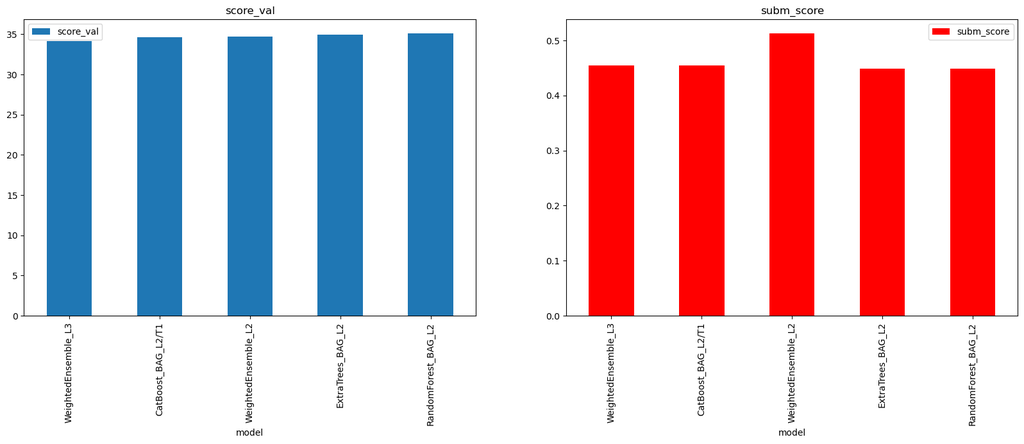

```python
plot_eval_and_kaggle_scores(best_models_leaderboard, 'img/best_models_leaderboard.png')
```

```python
hyperparameters = {
                    'RF': {},
                    'CAT': {},
                    'XT': {}
                  }

time_limit = 1500
num_trials = 5
search_strategy = 'auto'

hyperparameter_tune_kwargs = {
    'num_trials': num_trials,
    'scheduler' : 'local',
    'searcher': search_strategy,}
```

```python
predictor_best_models_stacking = TabularPredictor(label='count', eval_metric='root_mean_squared_error').fit(
    train.drop(['registered', 'casual'], axis=1),
    num_bag_folds=7, num_bag_sets=2, num_stack_levels=2,
    time_limit=time_limit,
    presets='best_quality',
    hyperparameters=hyperparameters,
    hyperparameter_tune_kwargs=hyperparameter_tune_kwargs,
)
```

```python
submit_top5(predictor_best_models_stacking, test, 'submission_best_models_stacking_top5', 'best models stacking top5')
```

```
Successfully submitted to Bike Sharing Demand
```

```python
time.sleep(10)
!kaggle competitions submissions -c bike-sharing-demand | tail -n +1 | head -n 9
```

```
fileName                                                             date                 description                                           status    publicScore  privateScore
-------------------------------------------------------------------  -------------------  ----------------------------------------------------  --------  -----------  ------------
submission_best_models_stacking_top5_ExtraTrees_BAG_L2.csv           2024-04-27 18:12:25  best models stacking top5 ExtraTrees_BAG_L2           complete  0.44778      0.44778
submission_best_models_stacking_top5_CatBoost_BAG_L2_T1.csv          2024-04-27 18:12:21  best models stacking top5 CatBoost_BAG_L2/T1          complete  0.44958      0.44958
submission_best_models_stacking_top5_WeightedEnsemble_L2.csv         2024-04-27 18:12:16  best models stacking top5 WeightedEnsemble_L2         complete  0.52686      0.52686
submission_best_models_stacking_top5_WeightedEnsemble_L3.csv         2024-04-27 18:12:13  best models stacking top5 WeightedEnsemble_L3         complete  0.44681      0.44681
submission_best_models_stacking_top5_WeightedEnsemble_L4.csv         2024-04-27 18:12:04  best models stacking top5 WeightedEnsemble_L4         complete  0.46111      0.46111
submission_best_models_top5_RandomForest_BAG_L2.csv                  2024-04-27 17:49:45  best models top5 RandomForest_BAG_L2                  complete  0.44846      0.44846
submission_best_models_top5_ExtraTrees_BAG_L2.csv                    2024-04-27 17:49:41  best models top5 ExtraTrees_BAG_L2                    complete  0.44851      0.44851
tail: error writing 'standard output': Broken pipe
```

```python
best_models_stacking_leaderboard, best_models_stacking_model_eval_score, best_models_stacking_model_kaggle_score = get_submission_score(predictor_best_models_stacking)
```

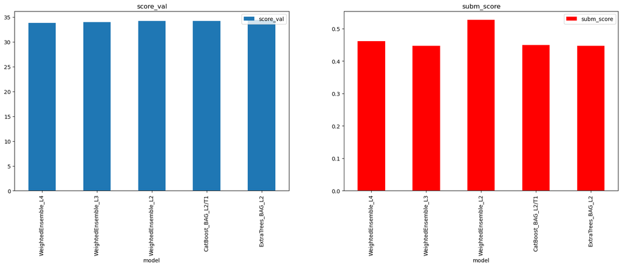

```python
plot_eval_and_kaggle_scores(best_models_stacking_leaderboard, 'img/best_models_stacking_leaderboard.png')
```

## Step 7: Write a Report

### Refer to the markdown file for the full report

### Creating plots and table for report

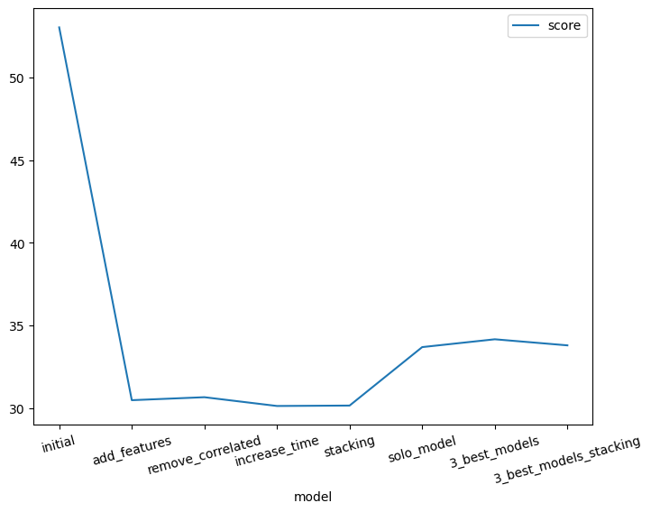

```python
# Taking the top model score from each training run and creating a line plot to show improvement
# You can create these in the notebook and save them to PNG or use some other tool (e.g. google sheets, excel)
fig = pd.DataFrame(
    {
        "model": ["initial", "add_features", "remove_correlated", "increase_time",
                  "stacking", "solo_model", "3_best_models", "3_best_models_stacking"],
        "score": [initial_model_eval_score,
                  new_features_model_eval_score,
                  new_feature_plus_remove_model_eval_score,
                  new_hpo_time_model_eval_score,
                  stacking_model_eval_score,
                  solo_model_eval_score,
                  best_models_model_eval_score,
                  best_models_stacking_model_eval_score]
    }
).plot(x="model", y="score", figsize=(8, 6)).get_figure()
plt.xticks(rotation=15)
fig.savefig('img/model_train_score.png')
```

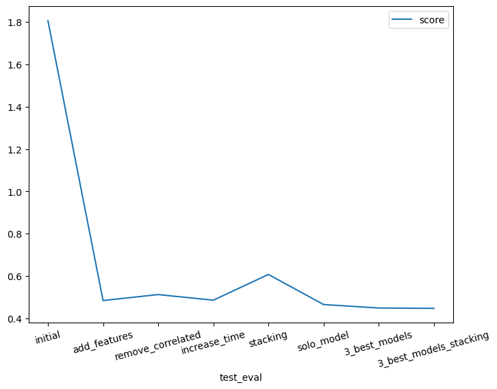

```python
# Take the 3 kaggle scores and creating a line plot to show improvement
fig = pd.DataFrame(
    {
        "test_eval": ["initial", "add_features", "remove_correlated", "increase_time",
                      "stacking", "solo_model", "3_best_models", "3_best_models_stacking"],
        "score": [float(initial_model_kaggle_score),
                  new_features_model_kaggle_score,
                  new_feature_plus_remove_model_kaggle_score,
                  new_hpo_time_model_kaggle_score,
                  stacking_model_kaggle_score,
                  solo_model_kaggle_score,
                  best_models_model_kaggle_score,
                  best_models_stacking_model_kaggle_score]
    }
).plot(x="test_eval", y="score", figsize=(8, 6)).get_figure()
plt.xticks(rotation=15)
fig.savefig('img/model_test_score.png')
```

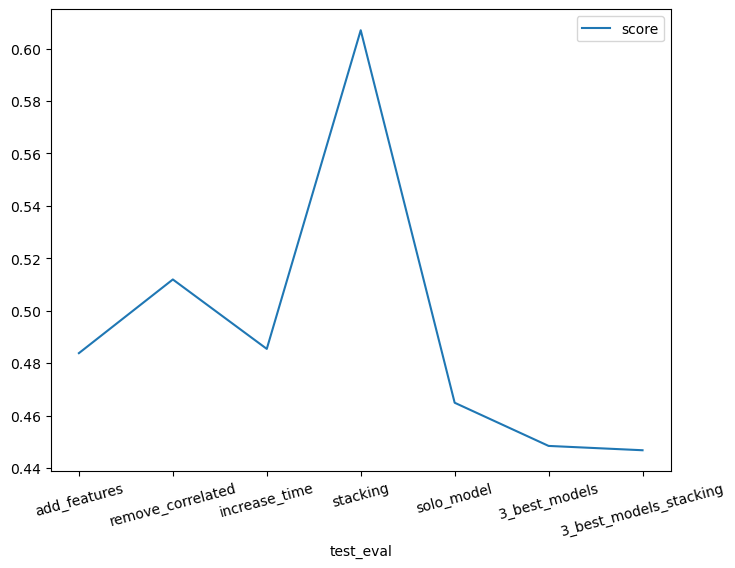

```python
fig = pd.DataFrame(
    {
        "test_eval": ["add_features", "remove_correlated", "increase_time",
                      "stacking", "solo_model", "3_best_models", "3_best_models_stacking"],
        "score": [
                  new_features_model_kaggle_score,
                  new_feature_plus_remove_model_kaggle_score,
                  new_hpo_time_model_kaggle_score,
                  stacking_model_kaggle_score,
                  solo_model_kaggle_score,
                  best_models_model_kaggle_score,
                  best_models_stacking_model_kaggle_score]
    }
).plot(x="test_eval", y="score", figsize=(8, 6)).get_figure()
plt.xticks(rotation=15)
fig.savefig('img/model_test_score_without_initial.png')
```

### Hyperparameter table

```python
# The 3 hyperparameters we tuned with the kaggle score as the result
table_df = pd.DataFrame({
    "model": ["initial", "add_features", "hpo_time", "hpo_stacking"],
    "time_limit": [600, 600, 1200, 1200],
    "presets": ['best_quality', 'best_quality', 'best_quality', 'best_quality'],
    "num_bag_folds": ['None', 'None', 'None', 7],
    "num_bag_sets": ['None', 'None', 'None', 2],
    "num_stack_levels": ['None', 'None', 'None', 2],
    "score": [initial_model_kaggle_score,
              new_features_model_kaggle_score,
              new_hpo_time_model_kaggle_score,
              stacking_model_kaggle_score]
})
table_df
```

|  | model | time_limit | presets | num_bag_folds | num_bag_sets | num_stack_levels | score |
| --- | --- | --- | --- | --- | --- | --- | --- |
| 0 | initial | 600 | best_quality | None | None | None | 1.80625 |
| 1 | add_features | 600 | best_quality | None | None | None | 0.48384 |
| 2 | hpo_time | 1200 | best_quality | None | None | None | 0.48547 |
| 3 | hpo_stacking | 1200 | best_quality | 7 | 2 | 2 | 0.607 |